# Statistics for quantitative mass spectrometry - Day 1

Section 3 : MSstats, Differential abundance and sample size calculation

Meena Choi

5/8/2017

# Summary

- Significance analysis for MS proteomics based peak intenesities data

## Data

- The processed data, `quant.skyline.rda`, which is output of `dataProcess` from [section 2](https://github.com/MayInstitute/MayInstitute2017/blob/master/Program5_Stat%20for%20MS/MayInst_P5_sec2.html)

# 0. Load the pre-processed data of Skyline output

Load MSstats first. Then you are ready to start MSstats.

```r
library(MSstats)
?MSstats
```

# 1. Load the processed data (output of `dataProcess`) of Skyline output

```r
load(file='./backup/data_Skyline/quant.skyline.rda')
```

# 2. Finding differentially abundant proteins across conditions

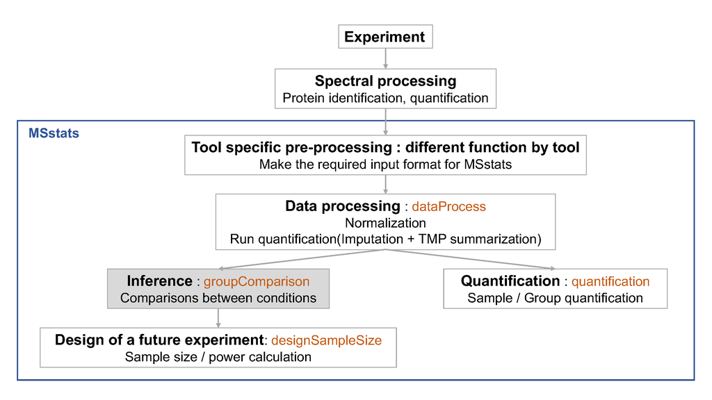

## 2.1 Assign contrast matrix

After we normalized the data and summarized each protein’s behaviour across conditions in `dataProcess` step, we are all set to compare protein changes between groups of conditions. Within MSstats we can do this with the `groupComparison` function, which takes as input the output of the `dataProcess` function.

```r
?groupComparison
```

We have to tell `groupComparison` which are the conditions we would like to compare. You can make your `contrast.matrix` in R in a text editor. We define our contrast matrix by adding a column for every condition, **in alphabetical order**. We add a row for every comparison we would like to make between groups of conditions.

**0** is for conditions we would like to ignore. **1** is for conditions we would like to put in the numerator of the ratio or fold-change. **-1** is for conditions we would like to put in the denumerator of the ratio or fold-change.

If you have multiple groups, you can assign any gruop comparisons you are interested in. For example, if you have 4 different conditions, Condition1, Condition2, Condition3, Condition4, there are many possible comparisons.

```r
# check unique conditions and check order of condition information
# In this case, Disease and Healthy
unique(quant.skyline$ProcessedData$GROUP_ORIGINAL)
```

```
## [1] Condition1 Condition2 Condition3 Condition4
## Levels: Condition1 Condition2 Condition3 Condition4
```

```r
comparison1<-matrix(c(-1,1,0,0),nrow=1)
comparison2<-matrix(c(-1,0,1,0),nrow=1)
comparison<-rbind(comparison1, comparison2)
row.names(comparison)<-c("C2-C1","C3-C1")

comparison
```

```
##       [,1] [,2] [,3] [,4]
## C2-C1   -1    1    0    0
## C3-C1   -1    0    1    0
```

> **Challenges**

> Make the matrix, named `comparison`, for all 6 paired comparision among 4 conditions (condition1, condition2, condition3, condition4)

```r
unique(quant.skyline$ProcessedData$GROUP_ORIGINAL)
```

```
## [1] Condition1 Condition2 Condition3 Condition4
## Levels: Condition1 Condition2 Condition3 Condition4
```

```r
comparison1<-matrix(c(-1,1,0,0),nrow=1)
comparison2<-matrix(c(-1,0,1,0),nrow=1)
comparison3<-matrix(c(-1,0,0,1),nrow=1)
comparison4<-matrix(c(0,-1,1,0),nrow=1)
comparison5<-matrix(c(0,-1,0,1),nrow=1)
comparison6<-matrix(c(0,0,-1,1),nrow=1)
comparison<-rbind(comparison1, comparison2, comparison3, comparison4, comparison5, comparison6)
row.names(comparison)<-c("C2-C1","C3-C1","C4-C1","C3-C2","C4-C2","C4-C3")

comparison
```

```
##       [,1] [,2] [,3] [,4]
## C2-C1   -1    1    0    0
## C3-C1   -1    0    1    0
## C4-C1   -1    0    0    1
## C3-C2    0   -1    1    0
## C4-C2    0   -1    0    1
## C4-C3    0    0   -1    1
```

## 2.2. Comparing conditions with `groupComparison`

`groupComparison` uses the run-level summarized data (`$RunlevelData` from `dataProcess` function) for hypothesis testing.

```r
test.skyline <- groupComparison(contrast.matrix=comparison, data=quant.skyline)
```

Let’s check the output.

```r
class(test.skyline)
```

```
## [1] "list"
```

```r
names(test.skyline)
```

```
## [1] "ComparisonResult" "ModelQC"          "fittedmodel"
```

```r
# Show test result
# Label : which comparison is used
# log2FC : estimated log2 fold change between Diseased and Healthy
# adj.pvalue : adjusted p value
# issue : detect whether this protein has any issue for comparison
#    such as, there is measurement in certain group, or no measurement at all.
# MissingPercentage : the number of missing intensities/total number of intensities
#     in conditions your are interested in for comparison
# ImputationPercentage : the number of imputed intensities/total number of intensities
#     in conditions your are interested in for comparison
head(test.skyline$ComparisonResult)
```

```
##                  Protein Label      log2FC         SE     Tvalue DF
## 1   sp|D6VTK4|STE2_YEAST C2-C1  0.07846162 0.09648008  0.8132416  8
## 7   sp|O13297|CET1_YEAST C2-C1 -0.11119732 0.07749333 -1.4349278  8
## 13  sp|O13329|FOB1_YEAST C2-C1 -0.16209422 0.29090086 -0.5572146  8
## 19  sp|O13539|THP2_YEAST C2-C1 -0.43742107 0.82871351 -0.5278315  8
## 25 sp|O13547|CCW14_YEAST C2-C1 -0.05774773 0.14672405 -0.3935805  8
## 31 sp|O13563|RPN13_YEAST C2-C1 -0.16945187 0.09518591 -1.7802201  8
##       pvalue adj.pvalue issue MissingPercentage ImputationPercentage
## 1  0.4396100  0.9991155    NA                 0                    0
## 7  0.1892233  0.9991155    NA                 0                    0
## 13 0.5926243  0.9991155    NA                 0                    0
## 19 0.6119387  0.9991155    NA                 0                    0
## 25 0.7041724  0.9991155    NA                 0                    0
## 31 0.1129126  0.9991155    NA                 0                    0
```

```r
# After fitting linear model, residuals and fitted values can be shown.
head(test.skyline$ModelQC)
```

```
##   RUN              PROTEIN ABUNDANCE NumMeasuredFeature MissingPercentage
## 1   1 sp|D6VTK4|STE2_YEAST  26.81232                  8                 0
## 2   2 sp|D6VTK4|STE2_YEAST  26.60786                  8                 0
## 3   3 sp|D6VTK4|STE2_YEAST  26.58301                  8                 0
## 4   4 sp|D6VTK4|STE2_YEAST  26.83563                  8                 0
## 5   5 sp|D6VTK4|STE2_YEAST  26.79430                  8                 0
## 6   6 sp|D6VTK4|STE2_YEAST  26.60863                  8                 0
##   more50missing NumImputedFeature               originalRUN GROUP
## 1         FALSE                 0 JD_06232014_sample1_B.raw     1
## 2         FALSE                 0 JD_06232014_sample1_C.raw     1
## 3         FALSE                 0 JD_06232014_sample1-A.raw     1
## 4         FALSE                 0 JD_06232014_sample2_A.raw     2
## 5         FALSE                 0 JD_06232014_sample2_B.raw     2
## 6         FALSE                 0 JD_06232014_sample2_C.raw     2
##   GROUP_ORIGINAL SUBJECT_ORIGINAL SUBJECT_NESTED SUBJECT   residuals
## 1     Condition1                1            1.1       1  0.14458899
## 2     Condition1                1            1.1       1 -0.05986794
## 3     Condition1                1            1.1       1 -0.08472105
## 4     Condition2                2            2.2       2  0.08944428
## 5     Condition2                2            2.2       2  0.04811446
## 6     Condition2                2            2.2       2 -0.13755874
##     fitted
## 1 26.66773
## 2 26.66773
## 3 26.66773
## 4 26.74619
## 5 26.74619
## 6 26.74619
```

```r
# Fitted model per protein
head(test.skyline$fittedmodel)
```

```
## [[1]]
##
## Call:
## lm(formula = ABUNDANCE ~ GROUP, data = data2)
##
## Coefficients:
## (Intercept)       GROUP2       GROUP3       GROUP4
##    26.66773      0.07846     -0.11566     -0.11841
##
##
## [[2]]
##
## Call:
## lm(formula = ABUNDANCE ~ GROUP, data = data2)
##
## Coefficients:
## (Intercept)       GROUP2       GROUP3       GROUP4
##    24.70386     -0.11120     -0.14451     -0.09633
##
##
## [[3]]
##
## Call:
## lm(formula = ABUNDANCE ~ GROUP, data = data2)
##
## Coefficients:
## (Intercept)       GROUP2       GROUP3       GROUP4
##     23.6207      -0.1621       0.1209      -0.3511
##
##
## [[4]]
##
## Call:
## lm(formula = ABUNDANCE ~ GROUP, data = data2)
##
## Coefficients:
## (Intercept)       GROUP2       GROUP3       GROUP4
##     26.4006      -0.4374      -0.4318      -0.5024
##
##
## [[5]]
##
## Call:
## lm(formula = ABUNDANCE ~ GROUP, data = data2)
##
## Coefficients:
## (Intercept)       GROUP2       GROUP3       GROUP4
##    27.04775     -0.05775     -0.29114     -0.09482
##
##
## [[6]]
##
## Call:
## lm(formula = ABUNDANCE ~ GROUP, data = data2)
##
## Coefficients:
## (Intercept)       GROUP2       GROUP3       GROUP4
##    26.18595     -0.16945     -0.07609     -0.21625
```

```r
test.skyline$fittedmodel[[1]]
```

```
##
## Call:
## lm(formula = ABUNDANCE ~ GROUP, data = data2)
##
## Coefficients:
## (Intercept)       GROUP2       GROUP3       GROUP4
##    26.66773      0.07846     -0.11566     -0.11841
```

## 2.3. Save the comparison result

Let’s save the testing result as .csv file.

```r
Skyline.result <- test.skyline$ComparisonResult

save(Skyline.result, file='./data_Skyline/Skyline.result.rda')
write.csv(Skyline.result, file='./data_Skyline/testResult_ABRF_skyline.csv')
```

## 2.4. subset of significant comparisons

```r
head(Skyline.result)
```

```
##                  Protein Label      log2FC         SE     Tvalue DF
## 1   sp|D6VTK4|STE2_YEAST C2-C1  0.07846162 0.09648008  0.8132416  8
## 7   sp|O13297|CET1_YEAST C2-C1 -0.11119732 0.07749333 -1.4349278  8
## 13  sp|O13329|FOB1_YEAST C2-C1 -0.16209422 0.29090086 -0.5572146  8
## 19  sp|O13539|THP2_YEAST C2-C1 -0.43742107 0.82871351 -0.5278315  8
## 25 sp|O13547|CCW14_YEAST C2-C1 -0.05774773 0.14672405 -0.3935805  8
## 31 sp|O13563|RPN13_YEAST C2-C1 -0.16945187 0.09518591 -1.7802201  8
##       pvalue adj.pvalue issue MissingPercentage ImputationPercentage
## 1  0.4396100  0.9991155    NA                 0                    0
## 7  0.1892233  0.9991155    NA                 0                    0
## 13 0.5926243  0.9991155    NA                 0                    0
## 19 0.6119387  0.9991155    NA                 0                    0
## 25 0.7041724  0.9991155    NA                 0                    0
## 31 0.1129126  0.9991155    NA                 0                    0
```

```r
# select subset of rows with adj.pvalue < 0.05
SignificantProteins <-
  Skyline.result[Skyline.result$adj.pvalue < 0.05 ,]

nrow(SignificantProteins)
```

```
## [1] 29
```

```r
# select subset of rows with adj.pvalue < 0.05 and log2FC > 2
SignificantProteinsUpInDiseased <- SignificantProteins[SignificantProteins$log2FC > 2 ,]

nrow(SignificantProteinsUpInDiseased)
```

```
## [1] 14
```

# 3. Visualization of differentially abundant proteins

```r
?groupComparisonPlots
```

## 3.1. Volcano plot

Volcano plots allow us to visually separate strong changes, which are not significant, from strong and significant changes. Look for these subjects in the upper right and upper left quadrants of the plot. Protein name will be shown only for siginificant proteins.

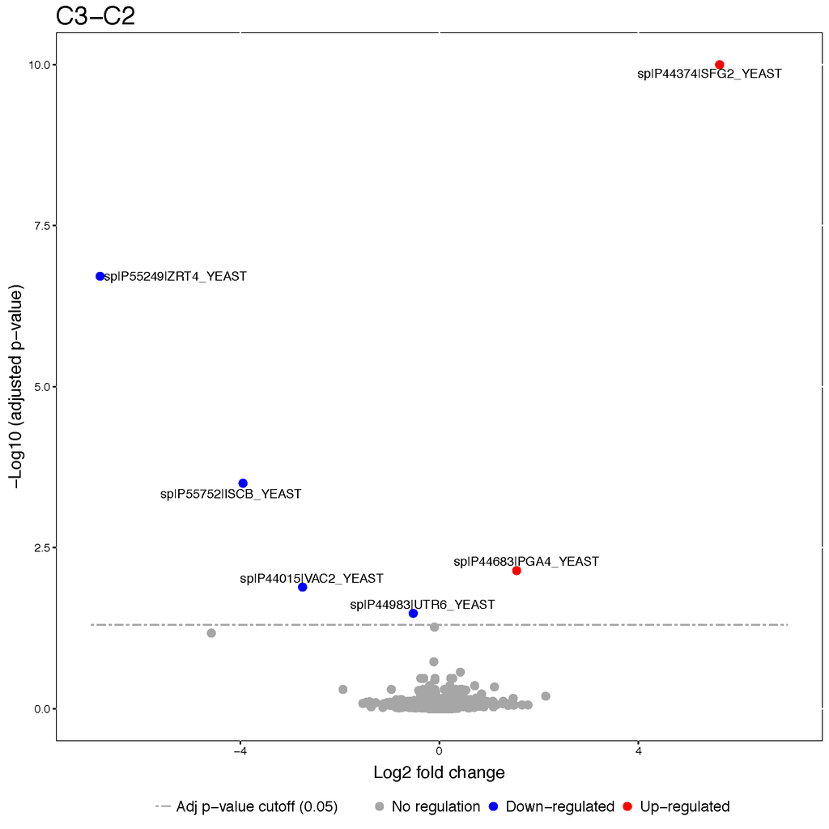

```r
groupComparisonPlots(data = Skyline.result,
                     type = 'VolcanoPlot',
                     address = './data_Skyline/testResult_ABRF_skyline_')
```

We can set up estimated fold change cutoff.

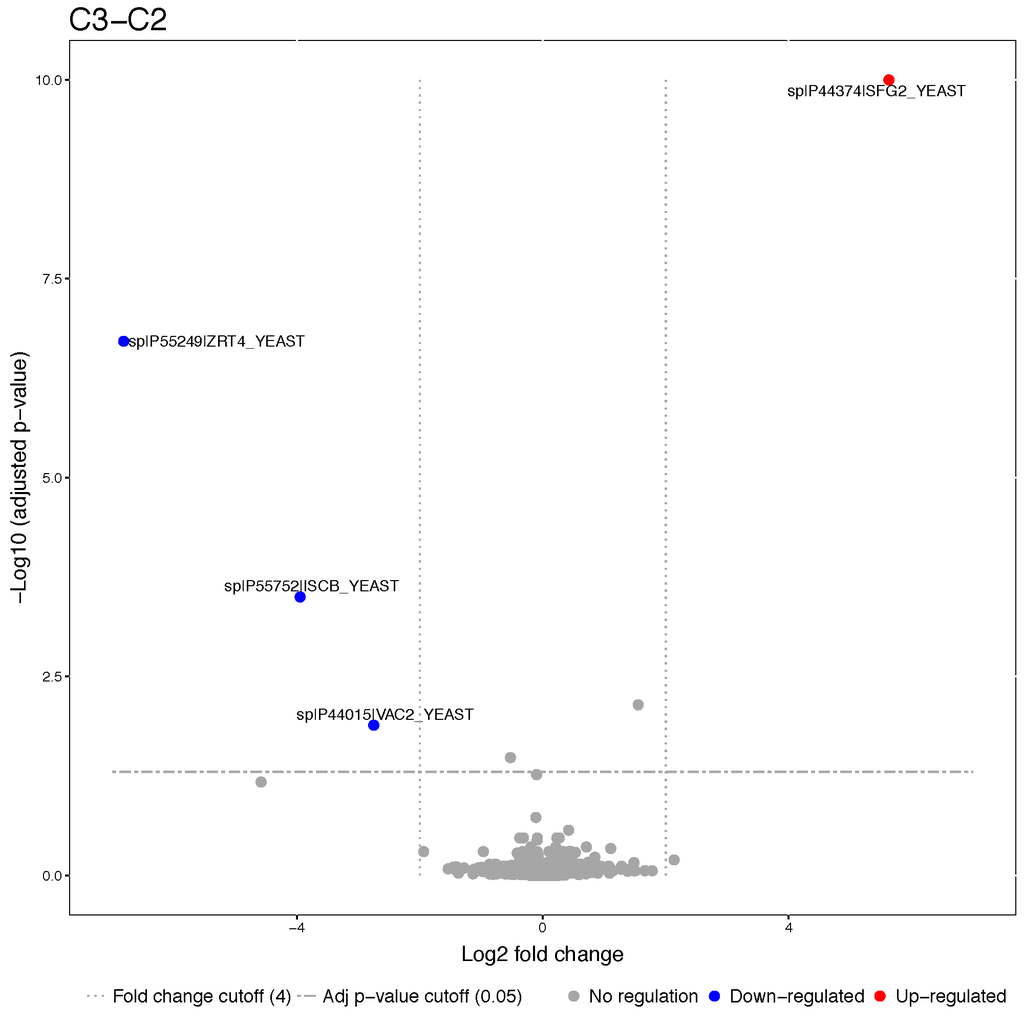

```r
groupComparisonPlots(data = Skyline.result,
                     type = 'VolcanoPlot',
                     sig = 0.05,
                     FCcutoff = 2^2,
                     address = './data_Skyline/testResult_ABRF_skyline_FCcutoff4_')
```

## 3.2. Comparison plot

Comparison plots illustrate model-based estimates of log-fold changes, and the associated uncertainty, in several comparisons of conditions for one protein. X-axis is the comparison of interest. Y-axis is the log fold change. The dots are the model-based estimates of log-fold change, and the error bars are the model-based 95% confidence intervals (the option sig can be used to change the significance level of significance). For simplicity, the confidence intervals are adjusted for multiple comparisons within protein only, using the Bonferroni approach. For proteins with N comparisons, the individual confidence intervals are at the level of 1-sig/N.

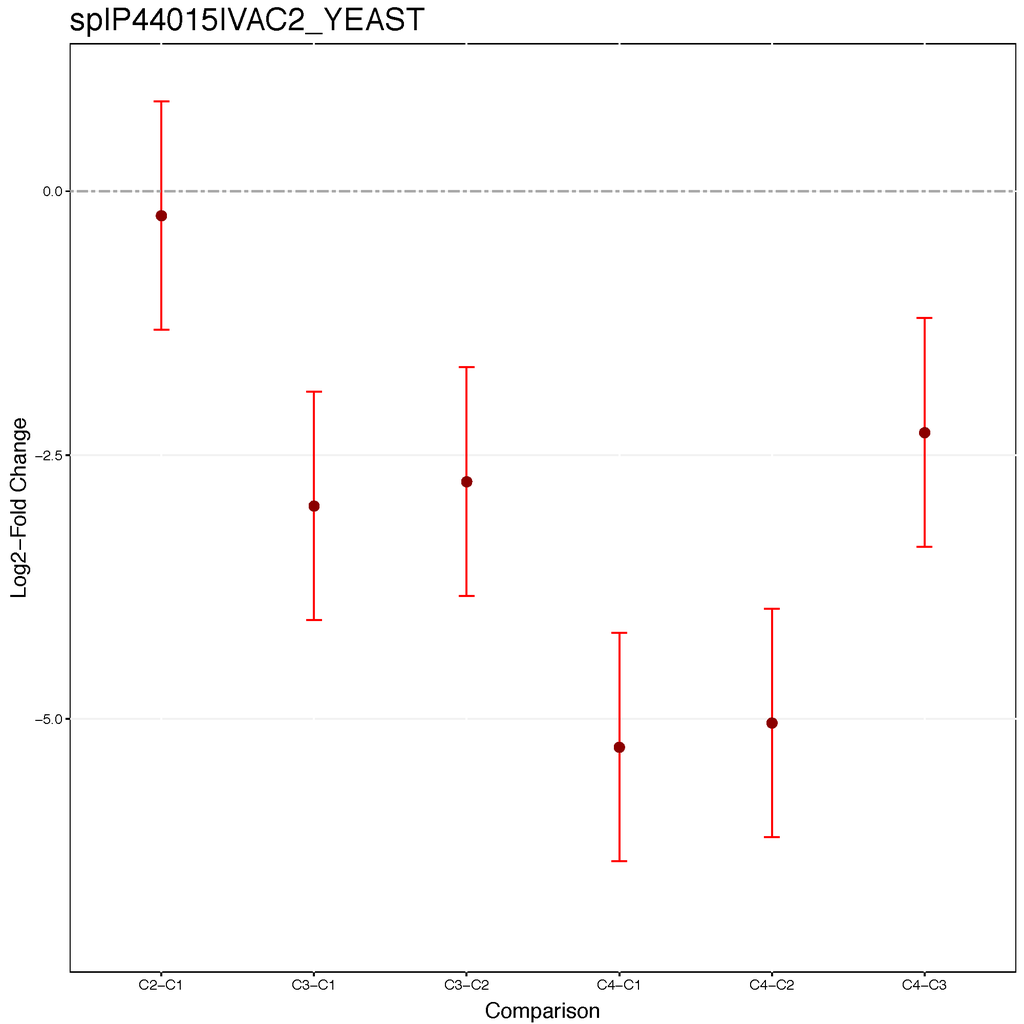

```r
groupComparisonPlots(Skyline.result,
                     type="ComparisonPlot",
                     address="./data_Skyline/testResult_ABRF_skyline_")
```

Let’s check the comparison result for protein `sp|P44015|VAC2_YEAST`.

```r
Skyline.result[Skyline.result$Protein == 'sp|P44015|VAC2_YEAST', ]
```

```
##                    Protein Label     log2FC        SE      Tvalue DF
## 10549 sp|P44015|VAC2_YEAST C2-C1 -0.2297095 0.3112305  -0.7380687  8
## 10550 sp|P44015|VAC2_YEAST C3-C1 -2.9802277 0.3112305  -9.5756284  8
## 10551 sp|P44015|VAC2_YEAST C4-C1 -5.2657554 0.3112305 -16.9191488  8
## 10552 sp|P44015|VAC2_YEAST C3-C2 -2.7505182 0.3112305  -8.8375597  8
## 10553 sp|P44015|VAC2_YEAST C4-C2 -5.0360459 0.3112305 -16.1810801  8
## 10554 sp|P44015|VAC2_YEAST C4-C3 -2.2855276 0.3112305  -7.3435204  8
##             pvalue   adj.pvalue issue MissingPercentage
## 10549 4.815597e-01 0.9991154610    NA                 0
## 10550 1.172208e-05 0.0088706850    NA                 0
## 10551 1.510378e-07 0.0001142978    NA                 0
## 10552 2.118219e-05 0.0128236969    NA                 0
## 10553 2.138408e-07 0.0001294592    NA                 0
## 10554 8.043885e-05 0.0608721006    NA                 0
##       ImputationPercentage
## 10549                    0
## 10550                    0
## 10551                    0
## 10552                    0
## 10553                    0
## 10554                    0
```

# 4. Planning future experimental designs

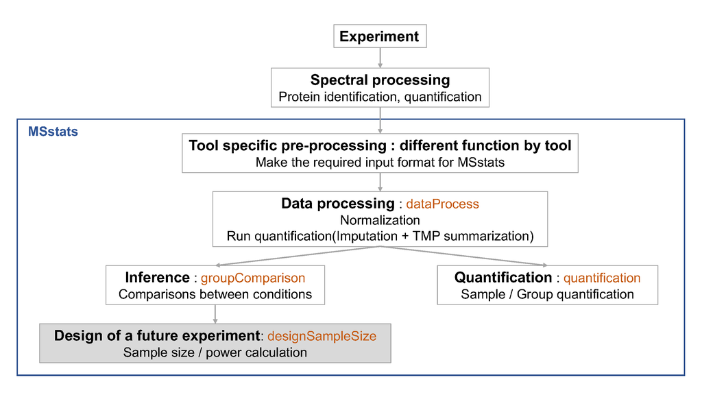

This last analysis step views the dataset as a pilot study of a future experiment, utilizes its variance components, and calculates the minimal number of replicates required in a future experiment to achieve the desired statistical power. The calculation is performed by the function `designSampleSize`, which takes as input the fitted model in `groupComparison`. Sample size calculation assumes same experimental design (i.e. group comparison, time course or paired design) as in the current dataset, and uses the model fit to estimate the median variance components across all the proteins. Finally, sample size calculation assumes that a large proportion of proteins (specifically, 99%) will not change in abundance in the future experiment. This assumption also provides conservative results. Using the estimated variance components, the function relates the number of biological replicates per condition (`numSample`, rounded to 0 decimal), average statistical power across all the proteins (`power`), minimal fold change that we would like to detect (can be specified as a range, e.g. `desiredFC=c(1.1, 2)`), and the False Discovery Rate (`FDR`). The user should specify all these quantities but one, and the function will solve for the remainder. The quantity to solve for should be set to `= TRUE`.

```r
?designSampleSize
```

## 4.1. Calculating statistical power

```r
# calculate the power
test.power <- designSampleSize(data = test.skyline$fittedmodel,
                               desiredFC = c(1.1, 1.6),
                               FDR = 0.05,
                               power = TRUE,
                               numSample = 3)
test.power
```

```
##    desiredFC numSample  FDR power    CV
## 1      1.100         3 0.05  0.01 0.010
## 2      1.125         3 0.05  0.01 0.010
## 3      1.150         3 0.05  0.01 0.010
## 4      1.175         3 0.05  0.01 0.010
## 5      1.200         3 0.05  0.03 0.009
## 6      1.225         3 0.05  0.09 0.009
## 7      1.250         3 0.05  0.19 0.009
## 8      1.275         3 0.05  0.31 0.009
## 9      1.300         3 0.05  0.45 0.009
## 10     1.325         3 0.05  0.58 0.009
## 11     1.350         3 0.05  0.69 0.008
## 12     1.375         3 0.05  0.78 0.008
## 13     1.400         3 0.05  0.85 0.008
## 14     1.425         3 0.05  0.90 0.008
## 15     1.450         3 0.05  0.94 0.008
## 16     1.475         3 0.05  0.96 0.008
## 17     1.500         3 0.05  0.98 0.008
## 18     1.525         3 0.05  0.99 0.007
## 19     1.550         3 0.05  0.99 0.007
## 20     1.575         3 0.05  0.99 0.007
## 21     1.600         3 0.05  0.99 0.007
```

## 4.2. Visualizing the relationship between desired fold-change and power

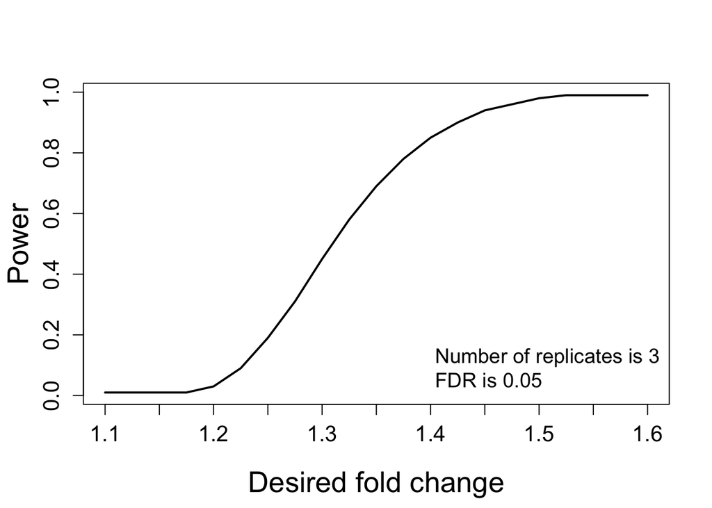

```r
designSampleSizePlots(data = test.power)
```

## 4.3. Designing sample size for desired fold-change

```r
# Minimal number of biological replicates per condition
samplesize <- designSampleSize(data = test.skyline$fittedmodel,
                               desiredFC = c(1.1, 1.6),
                               FDR = 0.05,
                               power = 0.9,
                               numSample = TRUE)
samplesize
```

```
##    desiredFC numSample  FDR power    CV
## 1      1.100        41 0.05   0.9 0.001
## 2      1.125        27 0.05   0.9 0.001
## 3      1.150        19 0.05   0.9 0.002
## 4      1.175        14 0.05   0.9 0.002
## 5      1.200        11 0.05   0.9 0.003
## 6      1.225         9 0.05   0.9 0.003
## 7      1.250         8 0.05   0.9 0.003
## 8      1.275         6 0.05   0.9 0.004
## 9      1.300         5 0.05   0.9 0.005
## 10     1.325         5 0.05   0.9 0.005
## 11     1.350         4 0.05   0.9 0.006
## 12     1.375         4 0.05   0.9 0.006
## 13     1.400         3 0.05   0.9 0.008
## 14     1.425         3 0.05   0.9 0.008
## 15     1.450         3 0.05   0.9 0.008
## 16     1.475         2 0.05   0.9 0.012
## 17     1.500         2 0.05   0.9 0.011
## 18     1.525         2 0.05   0.9 0.011
## 19     1.550         2 0.05   0.9 0.011
## 20     1.575         2 0.05   0.9 0.011
## 21     1.600         2 0.05   0.9 0.011
```

## 4.4. Visualizing the relationship between desired fold-change and mininum sample size number

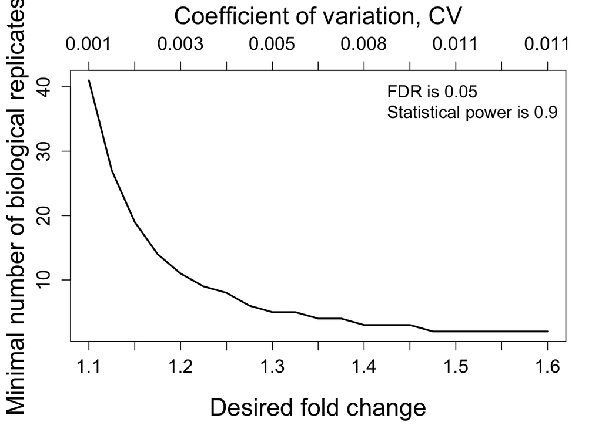

```r
designSampleSizePlots(data = samplesize)
```

# 5. Protein subject quantification

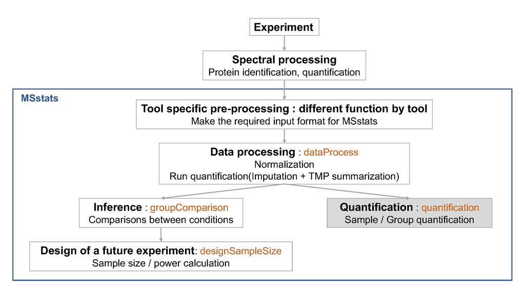

If there is no technical replicate, subject (or sample) quantification should be the same as run-level summarization. If there are technical replicates, subjet-level summarization(quantification) with run-level summarization will be useful for downstream analysis, such as classification.

```r
?quantification
```

```r
sampleQuant <- quantification(quant.skyline)
head(sampleQuant)
```

```
##                 Protein Condition1_1 Condition2_2 Condition3_3
## 1  sp|D6VTK4|STE2_YEAST     26.60786     26.79430     26.53029
## 2  sp|O13297|CET1_YEAST     24.71809     24.57865     24.62652
## 3  sp|O13329|FOB1_YEAST     23.47075     23.43427     23.73741
## 4  sp|O13539|THP2_YEAST     27.38510     25.90646     25.91799
## 5 sp|O13547|CCW14_YEAST     27.11638     26.91302     26.75541
## 6 sp|O13563|RPN13_YEAST     26.17056     26.01078     26.11412
##   Condition4_4
## 1     26.60612
## 2     24.64886
## 3     23.16646
## 4     25.91781
## 5     26.98082
## 6     26.05415
```

```r
groupQuant <- quantification(quant.skyline, type='Group')
head(groupQuant)
```

```
##                 Protein Condition1 Condition2 Condition3 Condition4
## 1  sp|D6VTK4|STE2_YEAST   26.60786   26.79430   26.53029   26.60612
## 2  sp|O13297|CET1_YEAST   24.71809   24.57865   24.62652   24.64886
## 3  sp|O13329|FOB1_YEAST   23.47075   23.43427   23.73741   23.16646
## 4  sp|O13539|THP2_YEAST   27.38510   25.90646   25.91799   25.91781
## 5 sp|O13547|CCW14_YEAST   27.11638   26.91302   26.75541   26.98082
## 6 sp|O13563|RPN13_YEAST   26.17056   26.01078   26.11412   26.05415
```

# 6. msstats.log and sessionInfo.txt

These two files are important to keep the records of package versions and options in functions.

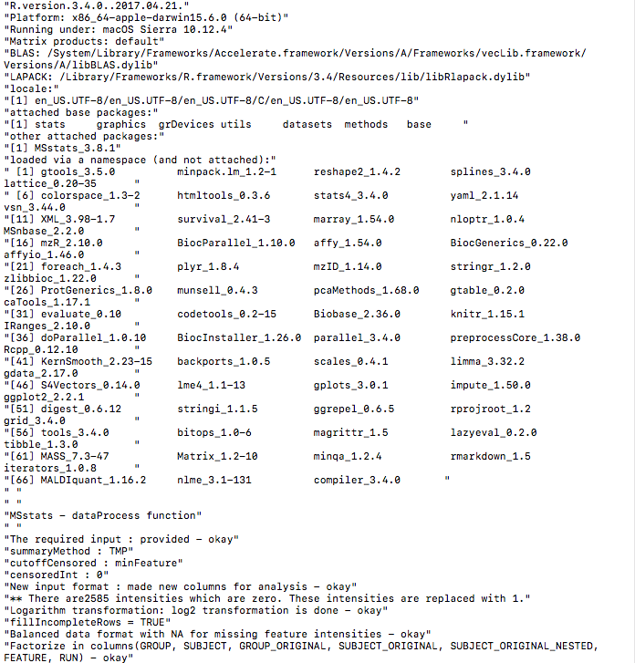

> **Challenges**
> 1. Load the processed data (output of dataProcess from section 2) of MaxQuant output and find the differentially abundant comparisons using `groupComparison` with the same `comparison` matrix.

```r
load(file='./backup/data_MaxQuant/quant.maxquant.rda')
```

```r
test.maxquant <- groupComparison(contrast.matrix=comparison, data=quant.maxquant)
MaxQuant.result <- test.maxquant$ComparisonResult
write.csv(MaxQuant.result, file='./backup/data_MaxQuant/testResult_ABRF_maxquant.csv')
```

> 2. Draw volcano plot with output of `groupComparison` with MaxQuant output.

```r
groupComparisonPlots(data = MaxQuant.result,
                     type = 'VolcanoPlot',
                     address = './backup/data_MaxQuant/testResult_ABRF_maxquant_')
```

> 3. Draw comparison plot with output of `groupComparison` with MaxQuant output. and Check the comparison plot for the protein, `P55249`.

```r
groupComparisonPlots(data = MaxQuant.result,
                     type = 'ComparisonPlot',
                     address = './backup/data_MaxQuant/testResult_ABRF_maxquant_')
```

> 4. Load the processed data (output of dataProcess from section 2) of Progenesis output and find the differentially abundant comparisons using `groupComparison` with the same `comparison` matrix.

```r
load(file='./backup/data_Progenesis/quant.progenesis.rda')
```

```r
test.progenesis <- groupComparison(contrast.matrix=comparison, data=quant.progenesis)
Progenesis.result <- test.progenesis$ComparisonResult
write.csv(Progenesis.result, file='./backup/data_Progenesis/testResult_ABRF_progenesis.csv')
```

> 5. Draw volcano plot with output of `groupComparison` with Progenesis output.

```r
groupComparisonPlots(data = Progenesis.result,
                     type = 'VolcanoPlot',
                     address = './backup/data_Progenesis/testResult_ABRF_progenesis_')
```

> 6. Draw comparison plot with output of `groupComparison` with Progenesis output. and Check the comparison plot for the protein, `sp|P55249|ZRT4_YEAST`

```r
groupComparisonPlots(data = Progenesis.result,
                     type = 'ComparisonPlot',
                     address = './backup/data_Progenesis/testResult_ABRF_progenesis_')
```

> 7. Compare the volcano plots for MaxQuant output and for Progenesis output.

Here is the experimental design for ABRF 2015 study.

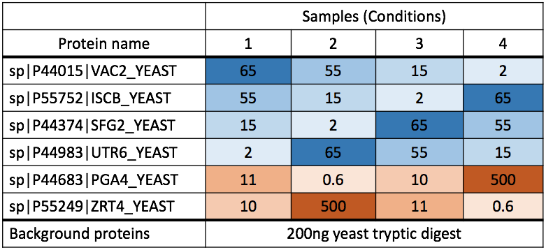